# Data Analysis to identify the potential customers who have a higher probability of purchasing the loan.

**The GOAL IS!**

- To sell more Personal Loan products to Bank customers.
- To devise campaigns to better target marketing to increase the success ratio with a minimal budget.
- To identify the potential customers who have a higher probability of purchasing the loan.

```python
import pandas as pd
import numpy as np
import matplotlib.pyplot as plot
import seaborn as sns
import statsmodels.api as sm
```

```python
# calculate accuracy measures and confusion matrix
from sklearn import metrics
from sklearn.linear_model import LogisticRegression
from sklearn.model_selection import train_test_split
from sklearn.metrics import accuracy_score, confusion_matrix, recall_score, precision_score, f1_score, auc
from sklearn.metrics import roc_curve, auc
from sklearn.neighbors import KNeighborsClassifier
from mlxtend.plotting import plot_confusion_matrix
from mlxtend.evaluate import confusion_matrix
from sklearn.naive_bayes import GaussianNB
# To enable plotting graphs in Jupyter notebook
%matplotlib inline
import warnings
warnings.filterwarnings('ignore')
```

```python
thera_df = pd.read_csv("Bank_Personal_Loan_Modelling-1.csv")
```

```python
thera_df.head(3)
```

|  | ID | Age | Experience | Income | ZIP Code | Family | CCAvg | Education | Mortgage | Personal Loan | Securities Account | CD Account | Online | CreditCard |
| --- | --- | --- | --- | --- | --- | --- | --- | --- | --- | --- | --- | --- | --- | --- |
| 0 | 1 | 25 | 1 | 49 | 91107 | 4 | 1.6 | 1 | 0 | 0 | 1 | 0 | 0 | 0 |
| 1 | 2 | 45 | 19 | 34 | 90089 | 3 | 1.5 | 1 | 0 | 0 | 1 | 0 | 0 | 0 |
| 2 | 3 | 39 | 15 | 11 | 94720 | 1 | 1.0 | 1 | 0 | 0 | 0 | 0 | 0 | 0 |

```python
thera_df.info()
```

```
<class 'pandas.core.frame.DataFrame'>
RangeIndex: 5000 entries, 0 to 4999
Data columns (total 14 columns):
ID                    5000 non-null int64
Age                   5000 non-null int64
Experience            5000 non-null int64
Income                5000 non-null int64
ZIP Code              5000 non-null int64
Family                5000 non-null int64
CCAvg                 5000 non-null float64
Education             5000 non-null int64
Mortgage              5000 non-null int64
Personal Loan         5000 non-null int64
Securities Account    5000 non-null int64
CD Account            5000 non-null int64
Online                5000 non-null int64
CreditCard            5000 non-null int64
dtypes: float64(1), int64(13)
memory usage: 546.9 KB
```

```python
# Check for No columns having null data in the file
thera_df.apply(lambda x : sum(x.isnull()))
```

```
ID                    0
Age                   0
Experience            0
Income                0
ZIP Code              0
Family                0
CCAvg                 0
Education             0
Mortgage              0
Personal Loan         0
Securities Account    0
CD Account            0
Online                0
CreditCard            0
dtype: int64
```

# Study the data distribution in each attribute, share your findings. (5 points)

```python
thera_df.describe().T
```

|  | count | mean | std | min | 25% | 50% | 75% | max |
| --- | --- | --- | --- | --- | --- | --- | --- | --- |
| ID | 5000.0 | 2500.500000 | 1443.520003 | 1.0 | 1250.75 | 2500.5 | 3750.25 | 5000.0 |
| Age | 5000.0 | 45.338400 | 11.463166 | 23.0 | 35.00 | 45.0 | 55.00 | 67.0 |
| Experience | 5000.0 | 20.104600 | 11.467954 | -3.0 | 10.00 | 20.0 | 30.00 | 43.0 |
| Income | 5000.0 | 73.774200 | 46.033729 | 8.0 | 39.00 | 64.0 | 98.00 | 224.0 |
| ZIP Code | 5000.0 | 93152.503000 | 2121.852197 | 9307.0 | 91911.00 | 93437.0 | 94608.00 | 96651.0 |
| Family | 5000.0 | 2.396400 | 1.147663 | 1.0 | 1.00 | 2.0 | 3.00 | 4.0 |
| CCAvg | 5000.0 | 1.937938 | 1.747659 | 0.0 | 0.70 | 1.5 | 2.50 | 10.0 |
| Education | 5000.0 | 1.881000 | 0.839869 | 1.0 | 1.00 | 2.0 | 3.00 | 3.0 |
| Mortgage | 5000.0 | 56.498800 | 101.713802 | 0.0 | 0.00 | 0.0 | 101.00 | 635.0 |
| Personal Loan | 5000.0 | 0.096000 | 0.294621 | 0.0 | 0.00 | 0.0 | 0.00 | 1.0 |
| Securities Account | 5000.0 | 0.104400 | 0.305809 | 0.0 | 0.00 | 0.0 | 0.00 | 1.0 |
| CD Account | 5000.0 | 0.060400 | 0.238250 | 0.0 | 0.00 | 0.0 | 0.00 | 1.0 |
| Online | 5000.0 | 0.596800 | 0.490589 | 0.0 | 0.00 | 1.0 | 1.00 | 1.0 |
| CreditCard | 5000.0 | 0.294000 | 0.455637 | 0.0 | 0.00 | 0.0 | 1.00 | 1.0 |

**Observation:**

- Column "Experience" has some negative value. Need to fix
- Binary variables "Personal Loan", "CreditCard", "Online", "CD Account", "Securities Account" has clean data
- Ordinary Categorial variables "Family" and "Education" are clean too

```python
thera_df.columns
```

```
Index(['ID', 'Age', 'Experience', 'Income', 'ZIP Code', 'Family', 'CCAvg',
       'Education', 'Mortgage', 'Personal Loan', 'Securities Account',
       'CD Account', 'Online', 'CreditCard'],
      dtype='object')
```

# Information on the attributes:

- ID: The variable ID does not add interesting information. We can drop this column for our model prediction or can make it our index.
- Age - Age of the customer.
- Experience - Years of experience.
- Income - Annual income in dollars.
- Zip Code -Home address zipcode. This column do not add value to for model and hence can be dropped.
- Family - Family size of the customer. It is a Categorical Variable.
- CCAvg - Average credit card spending per month in dollars.
- Education - Education Level. It is a Categorical Variable. 1: Undergrad; 2: Graduate; 3: Advanced/Professional
- Mortage - Value of House Mortgage in dollars.

**The binary category have five variables as below:**

- Personal Loan - Did this customer accept the personal loan offered in the last campaign? This is our **target variable.**
- Securities Account - Does the customer have a securities account with the bank?
- CD Account - Does the customer have a certificate of deposit (CD) account with the bank?
- Online - Does the customer use internet banking facilities?
- Credit Card - Does the customer use a credit card issued by UniversalBank?

# Get the target column distribution. Your comments

**Personal Loan** column is our **target column** as the management wants to explore ways of converting its liability customers to personal loan customers.

```python
thera_df.set_index('ID', drop=True, inplace=True)
thera_df.drop(['ZIP Code'], axis=1, inplace=True) #dropping column Zip code as it does not have any impact
thera_df.head(2)
```

| ID | Age | Experience | Income | Family | CCAvg | Education | Mortgage | Personal Loan | Securities Account | CD Account | Online | CreditCard |
| --- | --- | --- | --- | --- | --- | --- | --- | --- | --- | --- | --- | --- |
| 1 | 25 | 1 | 49 | 4 | 1.6 | 1 | 0 | 0 | 1 | 0 | 0 | 0 |
| 2 | 45 | 19 | 34 | 3 | 1.5 | 1 | 0 | 0 | 1 | 0 | 0 | 0 |

```python
thera_df.shape
```

```
(5000, 12)
```

```python
#finding unique data
thera_df.apply(lambda x: len(x.unique()))
```

```
Age                    45
Experience             47
Income                162
Family                  4
CCAvg                 108
Education               3
Mortgage              347
Personal Loan           2
Securities Account      2
CD Account              2
Online                  2
CreditCard              2
dtype: int64
```

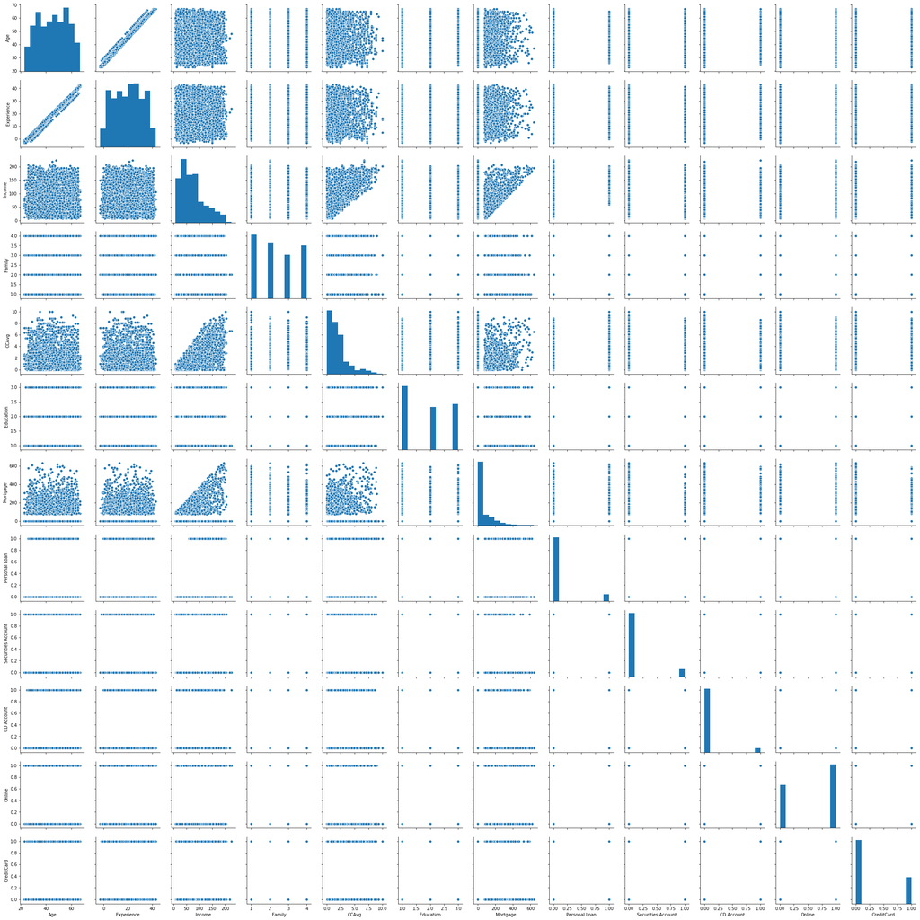

```python
# Pairplot using sns
sns.pairplot(thera_df)
```

```python
# there are 52 records with negative experience. Before proceeding further we need to clean the same
thera_df[thera_df['Experience'] < 0]['Experience'].count()
```

```
52
```

```python
#check the ammount of negative values
thera_df[thera_df['Experience'] < 0]['Experience'].value_counts()
```

```
-1    33
-2    15
-3     4
Name: Experience, dtype: int64
```

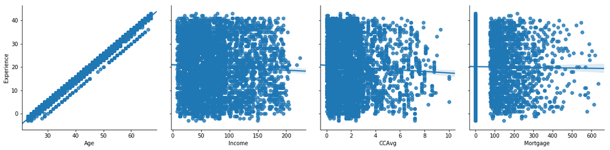

```python
ncol = ['Age', 'Income','CCAvg', 'Mortgage']
grid = sns.PairGrid(thera_df, y_vars = 'Experience', x_vars = ncol, height = 4)
grid.map(sns.regplot);
```

# 'Age' has a very strong association with 'Experience'

- It can be seen that the "Experience" variable has negative values, which could possibly mean some error in data.
- Hence let us replace those values with the absolute values as it could have been a typing error.
- Here we are not taking the mean value into consideration because the mean of Experience column is 20 years.

```python
thera_df['Experience'] = thera_df["Experience"].abs()
thera_df.describe().transpose()
```

|  | count | mean | std | min | 25% | 50% | 75% | max |
| --- | --- | --- | --- | --- | --- | --- | --- | --- |
| Age | 5000.0 | 45.338400 | 11.463166 | 23.0 | 35.0 | 45.0 | 55.0 | 67.0 |
| Experience | 5000.0 | 20.134600 | 11.415189 | 0.0 | 10.0 | 20.0 | 30.0 | 43.0 |
| Income | 5000.0 | 73.774200 | 46.033729 | 8.0 | 39.0 | 64.0 | 98.0 | 224.0 |
| Family | 5000.0 | 2.396400 | 1.147663 | 1.0 | 1.0 | 2.0 | 3.0 | 4.0 |
| CCAvg | 5000.0 | 1.937938 | 1.747659 | 0.0 | 0.7 | 1.5 | 2.5 | 10.0 |
| Education | 5000.0 | 1.881000 | 0.839869 | 1.0 | 1.0 | 2.0 | 3.0 | 3.0 |
| Mortgage | 5000.0 | 56.498800 | 101.713802 | 0.0 | 0.0 | 0.0 | 101.0 | 635.0 |
| Personal Loan | 5000.0 | 0.096000 | 0.294621 | 0.0 | 0.0 | 0.0 | 0.0 | 1.0 |
| Securities Account | 5000.0 | 0.104400 | 0.305809 | 0.0 | 0.0 | 0.0 | 0.0 | 1.0 |
| CD Account | 5000.0 | 0.060400 | 0.238250 | 0.0 | 0.0 | 0.0 | 0.0 | 1.0 |
| Online | 5000.0 | 0.596800 | 0.490589 | 0.0 | 0.0 | 1.0 | 1.0 | 1.0 |
| CreditCard | 5000.0 | 0.294000 | 0.455637 | 0.0 | 0.0 | 0.0 | 1.0 | 1.0 |

```python
# checking if there are records with negative experience
thera_df[thera_df['Experience'] < 0]['Experience'].count()
```

```
0
```

```python
thera_df.groupby(["Personal Loan"]).count()
```

| Personal Loan | Age | Experience | Income | Family | CCAvg | Education | Mortgage | Securities Account | CD Account | Online | CreditCard |
| --- | --- | --- | --- | --- | --- | --- | --- | --- | --- | --- | --- |
| 0 | 4520 | 4520 | 4520 | 4520 | 4520 | 4520 | 4520 | 4520 | 4520 | 4520 | 4520 |
| 1 | 480 | 480 | 480 | 480 | 480 | 480 | 480 | 480 | 480 | 480 | 480 |

- From the above we can see that the data is having a huge bias (almost 1:10) towards the category of people not accepting the personal loan

```python
rel_df = thera_df[['Personal Loan', 'Age', 'Income', 'Family','CCAvg', 'Education','Mortgage']]
rel_df.corr()
```

|  | Personal Loan | Age | Income | Family | CCAvg | Education | Mortgage |
| --- | --- | --- | --- | --- | --- | --- | --- |
| Personal Loan | 1.000000 | -0.007726 | 0.502462 | 0.061367 | 0.366889 | 0.136722 | 0.142095 |
| Age | -0.007726 | 1.000000 | -0.055269 | -0.046418 | -0.052012 | 0.041334 | -0.012539 |
| Income | 0.502462 | -0.055269 | 1.000000 | -0.157501 | 0.645984 | -0.187524 | 0.206806 |
| Family | 0.061367 | -0.046418 | -0.157501 | 1.000000 | -0.109275 | 0.064929 | -0.020445 |
| CCAvg | 0.366889 | -0.052012 | 0.645984 | -0.109275 | 1.000000 | -0.136124 | 0.109905 |
| Education | 0.136722 | 0.041334 | -0.187524 | 0.064929 | -0.136124 | 1.000000 | -0.033327 |
| Mortgage | 0.142095 | -0.012539 | 0.206806 | -0.020445 | 0.109905 | -0.033327 | 1.000000 |

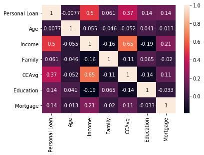

```python
sns.heatmap(rel_df.corr(), annot = True);
```

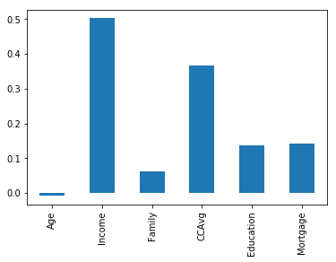

```python
rel_df.corr()['Personal Loan'][1:].plot.bar();
```

**'Age', 'Family','Education' and 'Mortgage' have very low correlation coef with Personal Loan. We may say that only 'Income' and 'CCAvg' have high association with 'Personal Loan'**

# Split the data into training and test set in the ratio of 70:30 respectively

```python
X = thera_df.drop("Personal Loan", axis=1)
y = thera_df["Personal Loan"]
```

```python
X.head()
```

| ID | Age | Experience | Income | Family | CCAvg | Education | Mortgage | Securities Account | CD Account | Online | CreditCard |
| --- | --- | --- | --- | --- | --- | --- | --- | --- | --- | --- | --- |
| 1 | 25 | 1 | 49 | 4 | 1.6 | 1 | 0 | 1 | 0 | 0 | 0 |
| 2 | 45 | 19 | 34 | 3 | 1.5 | 1 | 0 | 1 | 0 | 0 | 0 |
| 3 | 39 | 15 | 11 | 1 | 1.0 | 1 | 0 | 0 | 0 | 0 | 0 |
| 4 | 35 | 9 | 100 | 1 | 2.7 | 2 | 0 | 0 | 0 | 0 | 0 |
| 5 | 35 | 8 | 45 | 4 | 1.0 | 2 | 0 | 0 | 0 | 0 | 1 |

```python
from sklearn.preprocessing import MinMaxScaler
scaler = MinMaxScaler()
x_scaled = scaler.fit_transform(X)
X = pd.DataFrame(x_scaled)
X.columns=['Age','Experience','Income','Family','CCAvg','Education',
           'Mortgage','Securities Account','CD Account','Online','CreditCard']
```

```python
test_size = 0.3
seed = 7  # Random number seeding for reapeatability of the code
X_train, X_test, y_train, y_test = train_test_split(X, y, test_size=test_size, random_state=seed)
```

# Use different classification models (Logistic, K-NN and Naïve Bayes) to predict the likelihood of a liability customer buying personal loans (15 points)

# Print the confusion matrix for all the above models (5 points)

# Logistic Regression Model

```python
model = LogisticRegression()
model.fit(X_train, y_train)
```

```
LogisticRegression(C=1.0, class_weight=None, dual=False, fit_intercept=True,
          intercept_scaling=1, max_iter=100, multi_class='warn',
          n_jobs=None, penalty='l2', random_state=None, solver='warn',
          tol=0.0001, verbose=0, warm_start=False)
```

```python
y_predict = model.predict(X_test)
logmodel_score = model.score(X_test, y_test)
logmodel_score
```

```
0.9546666666666667
```

```python
sum(y_test)
```

```
138
```

```python
y_predictProb = model.predict_proba(X_train)
fpr, tpr, thresholds = roc_curve(y_train, y_predictProb[::,1])
roc_auc = auc(fpr, tpr)
roc_auc
```

```
0.9563283075749326
```

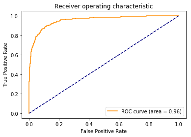

```python
plot.plot(fpr, tpr, color='darkorange', label='ROC curve (area = %0.2f)' % roc_auc)
plot.plot([0, 1], [0, 1], color='navy', linestyle='--')
plot.xlabel('False Positive Rate')
plot.ylabel('True Positive Rate')
plot.title('Receiver operating characteristic')
plot.legend(loc="lower right")
```

```python
optimalF1 = 0
optimalTh = 0
thresholds[0:10]
for th in thresholds:
    preds = np.where(model.predict_proba(X_train)[:,1] > th, 1, 0)
    f1Score = f1_score(y_train, preds)
    if(optimalF1 < f1Score):
        optimalF1 = f1Score
        optimalTh = th
```

```python
THRESHOLD = optimalTh
```

```python
preds = np.where(model.predict_proba(X_test)[:,1] > THRESHOLD, 1, 0)
```

```python
pd.DataFrame(data=[accuracy_score(y_test, preds),
                   recall_score(y_test, preds),
                   precision_score(y_test, preds),
                   f1_score(y_test, preds)],
             index=["accuracy", "recall", "precision", "f1_score"])
```

|  | 0 |
| --- | --- |
| accuracy | 0.950667 |
| recall | 0.666667 |
| precision | 0.766667 |
| f1_score | 0.713178 |

# Calculate optimal probability threshold from train data

```python
X_train.shape[0]
```

```
3500
```

```python
def logisticRegModelPerformanceAnalysis(X, y, test_size = 0.3, seed = 7):
    X_train, X_test, y_train, y_test = train_test_split(X, y, test_size=test_size, random_state=seed)
    model = LogisticRegression()
    model.fit(X_train, y_train)
    ### Unoptimized probability threshold based performance numbers
    # Train accuracy numbers
    trainPreds = np.where(model.predict_proba(X_train)[:,1] > 0.5, 1, 0)
    trainAccuracy = accuracy_score(y_train, trainPreds)
    trainRecall = recall_score(y_train, trainPreds)
    trainPrecision = precision_score(y_train, trainPreds)
    trainF1score = f1_score(y_train, trainPreds)
    trainResults=[X_train.shape[0], 0.5, trainAccuracy, trainRecall, trainPrecision, trainF1score]
    # Test accuracy numbers
    testPreds = np.where(model.predict_proba(X_test)[:,1] > 0.5, 1, 0)
    testAccuracy = accuracy_score(y_test, testPreds)
    testRecall = recall_score(y_test, testPreds)
    testPrecision = precision_score(y_test, testPreds)
    testF1score = f1_score(y_test, testPreds)
    testResults=[X_test.shape[0], 0.5, testAccuracy, testRecall, testPrecision, testF1score]

    #### Optimize probability threshold and calculate performance numbers
    y_predictProb = model.predict_proba(X_train)
    fpr, tpr, thresholds = roc_curve(y_train, y_predictProb[::,1])
    optimalF1 = 0
    optimalTh = 0
    for th in thresholds:
        preds = np.where(model.predict_proba(X_train)[:,1] > th, 1, 0)
        f1Score = f1_score(y_train, preds)
        if(optimalF1 < f1Score):
            optimalF1 = f1Score
            optimalTh = th

    # Optimal probability threshold based train accuracy numbers
    trainPreds = np.where(model.predict_proba(X_train)[:,1] > optimalTh, 1, 0)
    trainAccuracy = accuracy_score(y_train, trainPreds)
    trainRecall = recall_score(y_train, trainPreds)
    trainPrecision = precision_score(y_train, trainPreds)
    trainF1score = f1_score(y_train, trainPreds)
    optimalTrainResults=[X_train.shape[0], optimalTh, trainAccuracy, trainRecall, trainPrecision, trainF1score]
    # Optimal probability threshold based test accuracy numbers
    testPreds = np.where(model.predict_proba(X_test)[:,1] > optimalTh, 1, 0)
    testAccuracy = accuracy_score(y_test, testPreds)
    testRecall = recall_score(y_test, testPreds)
    testPrecision = precision_score(y_test, testPreds)
    testF1score = f1_score(y_test, testPreds)
    optimalTestResults=[X_test.shape[0], optimalTh, testAccuracy, testRecall, testPrecision, testF1score]
    # Concatenate Train and Test results to resultsDf
    resultsDf = pd.DataFrame( index=["dataSize", "optimalTh", "accuracy", "recall", "precision", "f1_score"])
    resultsDf['unOptimalTrainResults'] = trainResults
    resultsDf['unOptimalTestResults'] = testResults
    resultsDf['optimalTrainResults'] = optimalTrainResults
    resultsDf['optimalTestResults'] = optimalTestResults

    return resultsDf.round(2)
```

```python
logisticRegModelPerformanceAnalysis(X, y, test_size = 0.3, seed = 7)
```

|  | unOptimalTrainResults | unOptimalTestResults | optimalTrainResults | optimalTestResults |
| --- | --- | --- | --- | --- |
| dataSize | 3500.00 | 1500.00 | 3500.00 | 1500.00 |
| optimalTh | 0.50 | 0.50 | 0.37 | 0.37 |
| accuracy | 0.95 | 0.95 | 0.95 | 0.95 |
| recall | 0.55 | 0.59 | 0.66 | 0.67 |
| precision | 0.87 | 0.88 | 0.80 | 0.77 |
| f1_score | 0.67 | 0.70 | 0.73 | 0.71 |

```python
lr_cm = metrics.confusion_matrix(y_predict, y_test)
print(" Confusion Matrix: \n",lr_cm)
```

```
 Confusion Matrix:
 [[1351   57]
 [  11   81]]
```

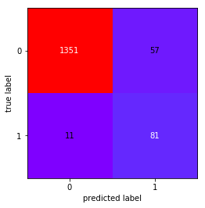

```python
fig, ax = plot_confusion_matrix(conf_mat=lr_cm,cmap = "rainbow")

plot.show()
```

**Analyzing the confusion matrix**

- True Positives (TP): we correctly predicted that they will purchase loan 81
- True Negatives (TN): we correctly predicted that they don't purchase loan 1351
- False Positives (FP): we incorrectly predicted that they will purchase loan (a "Type I error") 11 Falsely predict positive Type I error
- False Negatives (FN): we incorrectly predicted that they don't purchase loan (a "Type II error") 57 Falsely predict negative Type II error